# XVA Workbook

## Step 0 - Define a test swap to run XVA:

```python
# Helper function for curve building please refer to previous post
# Pull out a yield curve for pricing
# Details please refer to previous workbook, we will use USD LIBOR curve here.
Con_dict = {
# All details listed here is directly from the market instruments
# If changed to another sets of market instruments please update details here!
    "Cash":{ "DayCount":ql.Actual360(),
             "EOM":False, # Check if end of month please change correspondingly
             "BsDay":ql.ModifiedFollowing,
             "Calendar":ql.UnitedStates(),
             "SettlementDays": 2, # Settlement shift after fixing
           },
    "Future":{ "DayCount":ql.Actual360(),
               "EOM":False, # Check if end of month please change correspondingly
               "BsDay":ql.ModifiedFollowing,
               "ConVes_Adj":ql.QuoteHandle(ql.SimpleQuote(0.0)),# For convexity adjustment
               "Calendar":ql.UnitedStates(),
               "SettlementDays": 2, # Settlement shift after fixing
               "LengthInMonths": 3,
             },
    "Swap":{  "Index":ql.USDLibor(ql.Period(3,ql.Months)), # Floating Leg index rate
              "FloatingLegTenor":ql.Period(3,ql.Months),
              "FloatingLegFrequency":ql.Quarterly,
              "FloatingLegAdjustment":ql.ModifiedFollowing,
              "FloatingLegDayCounter":ql.Actual360(),
              "FixedLegFrequency":ql.Semiannual,
              "FixedLegTenor":ql.Period(6,ql.Months),
              "FixedLegAdjustment":ql.ModifiedFollowing,
              "FixedLegDayCounter":ql.Thirty360(),
              "SettlementDays": 2, # Settlement shift after fixing
              "Calendar":ql.UnitedStates(),
            },
}
Mkt_dict = {
    "SDate": ql.Date(18,11,2019), # Curve starting date
    "Cash":{ (1,ql.Months): 0.018325,
             (3,ql.Months): 0.019026,
             (6,ql.Months): 0.019185,
           },
    "Future":{ # IMM dates can be automated using above functions
               # For clearly here I keep it as inputs date values
               ql.Date(18,12,2019): 98.1125,
               ql.Date(18,3,2020): 98.325,
               ql.Date(17,6,2020): 98.415,
               ql.Date(16,9,2020): 98.49,
               ql.Date(16,9,2020): 98.49,
               ql.Date(16,9,2020): 98.55,
             },
    "Swap":{  (2,ql.Years): 0.01604,
              (3,ql.Years): 0.0157,
              (4,ql.Years): 0.01567,
              (5,ql.Years): 0.015785,
              (6,ql.Years): 0.01597,
              (7,ql.Years): 0.0162,
              (8,ql.Years): 0.016475,
              (9,ql.Years): 0.01677,
              (10,ql.Years): 0.01705,
              (11,ql.Years): 0.017315,
              (12,ql.Years): 0.01756,
              (15,ql.Years): 0.01811,
              (20,ql.Years): 0.01869,
              (25,ql.Years): 0.0189,
              (30,ql.Years): 0.018932,
              (40,ql.Years): 0.01873,
            },
}
def Bootstrapping( Market, Convention ):
    sDate = Market["SDate"]
    ql.Settings.instance().evaluationDate = sDate
    # Convert market quotes into QuantLib "Quote objects"
    deposits = Market["Cash"]
    futures  = Market["Future"]
    swaps    = Market["Swap"]
    deposits_con  = Convention["Cash"]
    futuresc_con  = Convention["Future"]
    swaps_con     = Convention["Swap"]
    for n,unit in deposits.keys():
        deposits[(n,unit)] = ql.SimpleQuote(deposits[(n,unit)])
    for d in futures.keys():
        futures[d] = ql.SimpleQuote(futures[d])
    for n,unit in swaps.keys():
        swaps[(n,unit)] = ql.SimpleQuote(swaps[(n,unit)])
    # Build up helpers for curve building
    depositHelpers = [ ql.DepositRateHelper( ql.QuoteHandle(deposits[(n,unit)]),
                                             ql.Period(n,unit), deposits_con["SettlementDays"],
                                             deposits_con["Calendar"], deposits_con["BsDay"],
                                             deposits_con["EOM"], deposits_con["DayCount"])
                       for n, unit in deposits.keys() ]
    futuresHelpers = [ ql.FuturesRateHelper( ql.QuoteHandle(futures[d]),
                                             d, futuresc_con["LengthInMonths"],
                                             futuresc_con["Calendar"], futuresc_con["BsDay"],
                                             futuresc_con["EOM"], futuresc_con["DayCount"],
                                             futuresc_con["ConVes_Adj"])
                       for d in futures.keys() ]
    swapHelpers = [ ql.SwapRateHelper( ql.QuoteHandle(swaps[(n,unit)]),
                                       ql.Period(n,unit), swaps_con["Calendar"],
                                       swaps_con["FixedLegFrequency"], swaps_con["FixedLegAdjustment"],
                                       swaps_con["FixedLegDayCounter"], swaps_con["Index"])
                    for n, unit in swaps.keys() ]
    # term-structure construction
    helpers = depositHelpers + futuresHelpers + swapHelpers # Helpers combined
    yts = ql.PiecewiseFlatForward( sDate, helpers, ql.Actual360()) # Forward curve defination
    yts.enableExtrapolation()
    return yts
# Generate USE LIBOR yield curve with TermStructure object
base_yts = Bootstrapping(Mkt_dict, Con_dict)
hyts = ql.RelinkableYieldTermStructureHandle(base_yts) # Build discounting curve into a term structure
```

*NOTE: here, the termstructure is defined based on period, meaning it is shifted date on current date. If we changed the evaluation date the whole termstructure will be bring forward. This is pretty stupid when we are running potential exposures.*

#### Swap Object Build: ATM swap with 1MM notional and DV01 = 659.

```python
# Swap object defined as a dictionary with float leg and fixed leg
# Inorder to advance date in Quantlib we have to use a calender object
t_calendar = ql.UnitedStates()
settle_date = ql.Date(1, 12, 2019)
maturity_date = ql.Date(1, 12, 2026)
LiborXm = ql.USDLibor(ql.Period(3, ql.Months),hyts)
V_Swap_Dict = {
    "Type":ql.VanillaSwap.Payer,
    "Notional":1000000,
    "Fixed_Leg":{
        "fixedSchedule":ql.Schedule( settle_date,
                                     maturity_date,
                                     ql.Period(6, ql.Months), ql.UnitedStates(),
                                     ql.ModifiedFollowing, ql.ModifiedFollowing,
                                     ql.DateGeneration.Forward, False),
        "fixedRate":0.0162, # Approx. ATM swap
        "fixedDayCount":ql.Thirty360(),
    },
    "Float_Leg":{
        "floatSchedule": ql.Schedule( settle_date,
                                      maturity_date,
                                      ql.Period(3, ql.Months), ql.UnitedStates(),
                                      ql.ModifiedFollowing, ql.ModifiedFollowing,
                                      ql.DateGeneration.Forward, False),
        "index":LiborXm,
        "spread":0,
        "floatingDayCount":ql.Actual360(),
    },
}
swap_test = ql.VanillaSwap(  V_Swap_Dict["Type"],
                             V_Swap_Dict["Notional"],
                             V_Swap_Dict["Fixed_Leg"]["fixedSchedule"],
                             V_Swap_Dict["Fixed_Leg"]["fixedRate"],
                             V_Swap_Dict["Fixed_Leg"]["fixedDayCount"],
                             V_Swap_Dict["Float_Leg"]["floatSchedule"],
                             V_Swap_Dict["Float_Leg"]["index"],
                             V_Swap_Dict["Float_Leg"]["spread"],
                             V_Swap_Dict["Float_Leg"]["floatingDayCount"] )
swap_engine = ql.DiscountingSwapEngine(hyts)
swap_test.setPricingEngine(swap_engine)
hyts.linkTo(base_yts)
ql.Settings.instance().evaluationDate = Mkt_dict["SDate"]
print("Current Date={:},NPV={:}".format(Mkt_dict["SDate"],swap_test.NPV()))
DV01 = abs(swap_test.fixedLegBPS())
print('DV01={}'.format(DV01))
```

```
Current Date=November 18th, 2019,NPV=-16.73897240376391
DV01=659.1436890765254
```

## Step 1 - Define short rate model engine:

I am using the paramaters calibrated from previous post, also in the below I use another helper fucntion to translate rate path into actual curve termstructure handler object.

```python
# Hull-White factor calibrated from short-rate model, see previous post
startDate = ql.Date(18, 11, 2019)
ql.Settings.instance().evaluationDate = startDate
a = 0.01647
sigma = 0.00712
volas = [ql.QuoteHandle(ql.SimpleQuote(sigma)),
         ql.QuoteHandle(ql.SimpleQuote(sigma))]
meanRev = [ql.QuoteHandle(ql.SimpleQuote(a))]
model = ql.Gsr(hyts, [startDate+100], volas, meanRev )
process = model.stateProcess()
# Define evaluation grid
date_grid = [startDate + ql.Period(i,ql.Months) for i in range(0,12*6)]
date_grid += [LiborXm.fixingDate(x) for x in V_Swap_Dict["Float_Leg"]["floatSchedule"]]
date_grid = np.sort(np.unique(date_grid))
time_grid = np.vectorize(lambda x: ql.ActualActual().yearFraction(startDate, x))(date_grid)
delta = time_grid[1:] - time_grid[:-1]
# Random number generator
seed = 1
urng = ql.MersenneTwisterUniformRng(seed)
usrg = ql.MersenneTwisterUniformRsg(len(time_grid)-1,urng)
generator = ql.InvCumulativeMersenneTwisterGaussianRsg(usrg)
```

#### Generate N paths for valuation

#### NOTE:

- We are simulating zerobond discounting factors with different starting date and different maturities.
- QuantLib has a complexed implementation of zerobond pricing with short rate model. But it will be Okay for you to only remember "model.zerobond(T, t, y(t))" calculate a zerocoupon bond starting at t maturity at T and conditional on y(t) model paramater.

```python
# Generate N paths
N = 2000
x = np.zeros((N, len(time_grid))) # Zero Rates paths
y = np.zeros((N, len(time_grid)))
# Zero bond maturities
pillars = np.array([0.0, 0.5, 1, 2, 3, 4, 5, 6, 7, 8, 9, 10])
zero_bonds = np.zeros((N, len(time_grid), len(pillars)))
for j in range(12):
    zero_bonds[:, 0, j] = model.zerobond(pillars[j], 0, 0)
for n in range(0,N):
    dWs = generator.nextSequence().value()
    for i in range(1, len(time_grid)):
        t0 = time_grid[i-1]
        t1 = time_grid[i]
        x[n,i] = process.expectation( t0, x[n,i-1], delta[i-1]) \
                + dWs[i-1] * process.stdDeviation( t0, x[n,i-1], delta[i-1])
        y[n,i] = (x[n,i] - process.expectation(0,0,t1)) / process.stdDeviation(0,0,t1)
        for j in range(12):
            zero_bonds[n, i, j] = model.zerobond(t1+pillars[j], t1, y[n, i])
```

#### Quick look for rate path starting from today.

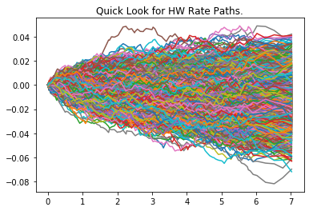

```python
# plot the paths
for i in range(0,N):
    plt.plot(time_grid, x[i,:])
plt.title("Quick Look for HW Rate Paths.")
```

## Step 2 - Run swap value on timegrid for all scenarios:

Here, I will use the procedure listed in the previous post to do swap valuation on a future date. The key point is to control the fixing date libor values.

*Please refer to the swap object we build previously*

*After MC simulation of different curves, now define timegrid and run swap values on curve X timegrid matrix*

```python
#Swap pricing under each scenario
val_mat = np.zeros((N,len(date_grid) ))
npv_mat = np.zeros((N,len(date_grid) ))
for p in range(0,N):
    ql.IndexManager.instance().clearHistories()
    for t in range(0, len(date_grid)):
        date = date_grid[t]
        ycDates =  [ date, date + ql.Period(6, ql.Months) ]
        ycDates += [ date + ql.Period(i,ql.Years) for i in range(1,11) ]
        yc = ql.DiscountCurve(ycDates,
                              zero_bonds[p, t, :],
                              ql.Actual365Fixed())
        yc.enableExtrapolation()
        hyts.linkTo(yc)
        ql.Settings.instance().setEvaluationDate(date)
        if LiborXm.isValidFixingDate(date):
            fixing = LiborXm.fixing(date)
            LiborXm.addFixing(date, fixing)
        val_mat[p, t] = swap_test.NPV()
        npv_mat[p, t] = val_mat[p, t]*yc.discount(date)
```

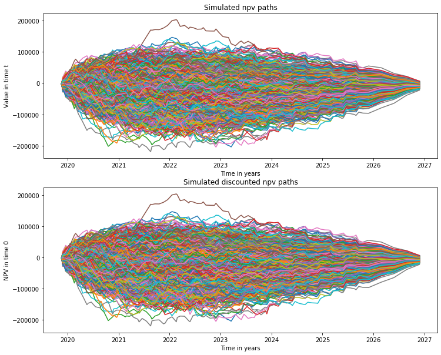

```python
f, (ax1, ax2) = plt.subplots(2, 1, figsize=(12,10), sharey=True)
x_dates = [dt.datetime(d.year(), d.month(), d.dayOfMonth()) for d in date_grid]
for cv in range(len(val_mat)):
    ax1.plot(x_dates,val_mat[cv])
    ax2.plot(x_dates,npv_mat[cv])
ax1.set_xlabel("Time in years")
ax1.set_ylabel("Value in time t")
ax1.set_title("Simulated npv paths")
ax2.set_xlabel("Time in years")
ax2.set_ylabel("NPV in time 0")
ax2.set_title("Simulated discounted npv paths")
```

## Step 3 - Potential Exposure & Default Curve:

**NOTE: For CVA calculation we use positive pontential exposure and for DVA use negative potential exposure.**

The following code is used to calculate potential exposure:

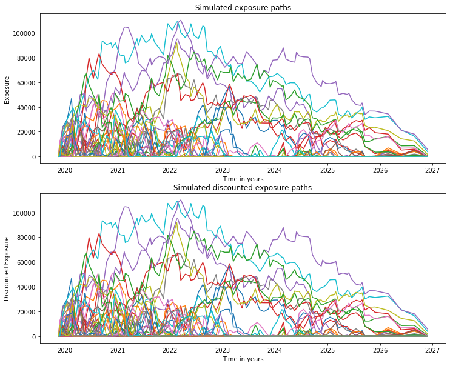

```python
# Calculate the exposure and discounted exposure
x_dates = [dt.datetime(d.year(), d.month(), d.dayOfMonth()) for d in date_grid]
E = val_mat.copy()
dE = npv_mat.copy()
E[E<0] = 0
dE[dE<0] = 0
# Plot the first 50 exposure paths
f, (ax1, ax2) = plt.subplots(2, 1, figsize=(12,10))
for cv in range(50):
    ax1.plot(x_dates, E[cv])
    ax2.plot(x_dates, dE[cv])
ax1.set_xlabel("Time in years")
ax1.set_ylabel("Exposure")
ax1.set_title("Simulated exposure paths")
ax2.set_xlabel("Time in years")
ax2.set_ylabel("Discounted Exposure")
ax2.set_title("Simulated discounted exposure paths")
```

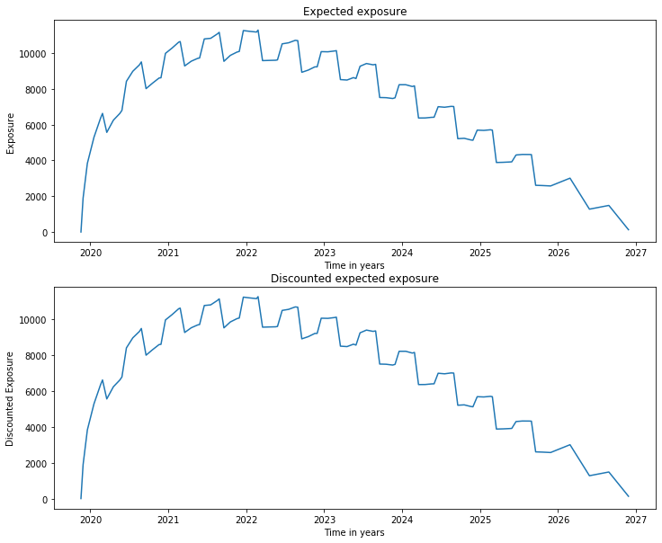

```python
# Calculate expected potential exposure path
x_dates = [dt.datetime(d.year(), d.month(), d.dayOfMonth()) for d in date_grid]
EE = np.sum(E, axis=0)/len(E)
EdE = np.sum(dE, axis=0)/len(dE)
# Plot the first 30 exposure paths
f, (ax1, ax2) = plt.subplots(2, 1, figsize=(12,10))
ax1.plot(x_dates, EE)
ax2.plot(x_dates, EdE)
ax1.set_xlabel("Time in years")
ax1.set_ylabel("Exposure")
ax1.set_title("Expected exposure")
ax2.set_xlabel("Time in years")
ax2.set_ylabel("Discounted Exposure")
ax2.set_title("Discounted expected exposure")
```

```python
# Setup Default Curve
pd_max_y = 20
pd_dates =  [startDate + ql.Period(i, ql.Years) for i in range(pd_max_y)]
hzrates = [0.02 * i for i in range(pd_max_y)]
pd_curve = ql.HazardRateCurve(pd_dates,hzrates,ql.Actual365Fixed())
pd_curve.enableExtrapolation()
```

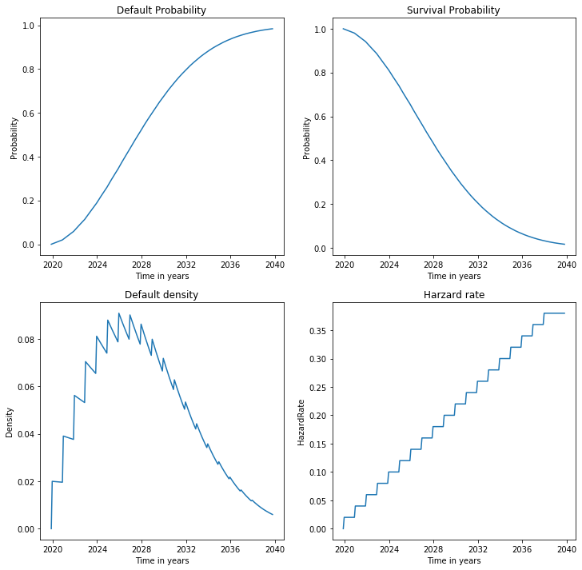

```python
# Plot curve
# Calculate default probs on grid *times*
pd_dates =  [startDate + ql.Period(i, ql.Months) for i in range(12*pd_max_y)]
x_pd_dates = [dt.datetime(d.year(), d.month(), d.dayOfMonth()) for d in pd_dates]
dp = np.vectorize(pd_curve.defaultProbability)(pd_dates)
sp = np.vectorize(pd_curve.survivalProbability)(pd_dates)
dd = np.vectorize(pd_curve.defaultDensity)(pd_dates)
hr = np.vectorize(pd_curve.hazardRate)(pd_dates)
f, ((ax1, ax2), (ax3, ax4)) = plt.subplots(2, 2, figsize=(12,12))
ax1.plot(x_pd_dates, dp)
ax2.plot(x_pd_dates, sp)
ax3.plot(x_pd_dates, dd)
ax4.plot(x_pd_dates, hr)
ax1.set_xlabel("Time in years")
ax2.set_xlabel("Time in years")
ax3.set_xlabel("Time in years")
ax4.set_xlabel("Time in years")
ax1.set_ylabel("Probability")
ax2.set_ylabel("Probability")
ax3.set_ylabel("Density")
ax4.set_ylabel("HazardRate")
ax1.set_title("Default Probability")
ax2.set_title("Survival Probability")
ax3.set_title("Default density")
ax4.set_title("Harzard rate")
```

**CVA(DVA) is the convolution of average potential positive(negative) value path with default probability for each piece.**

```python
# Calculation of the default probs
defaultProb_vec = np.vectorize(pd_curve.defaultProbability)
dPD = defaultProb_vec(date_grid[:-1], date_grid[1:])
# Calculation of the CVA
recovery = 0.4
CVA = (1-recovery) * np.sum(EdE[1:] * dPD)
print(CVA)
```

```
1628.3113582476083
```

#### EXPECTED Answer (Bloomberg Swaption Hedge Method):

#### 1633

## Summary

**Summary QA**:

- **Why we need to transfer zero curve in discounting curve with different starting points?** A: This is actualy a drawback using QuantLib, since this library does not allow the calcualtion on future dates with a fixed underlying yield curve. After building different discounting curves with different starting point(value points) we can use swap discounting engine to get its value.
- **Why the future exposure path has steeled value?** A: This is a common mistake when we deal with Monte-Carlo, since QuantLib has its own implementation of pricing date and fixing control. Please pay attention to the valuation matrix generation block. Basically, we need to reset valuaiton date and clear all fixing dates before running different curves.
- **How to calculate cva on portfolio with different swaps?** A: The most important part in this implementation is to calibrate short rate model. Inorder to make it accurate, please fisrt define a set of ATM swaption volatility to calibrate, suggestion could be calculate portfolio WAL weighted by notionals.